# Shooting Crime in New York City

December 10, 2024

This project provides a descriptive analysis of the shooting crimes in New York City (NYC). It primarily focuses on the demographic and geographic characteristics of shooting incidents. The analysis is based on New York Police Department (NYPD) Shooting Incident data https://catalog.data.gov/dataset/nypd-shooting-incident-data-historic.

## Data preparation

A simple description of the data shows that it contains multiple variables.

```
##   INCIDENT_KEY        OCCUR_DATE         OCCUR_TIME            BORO
##  Min.   :  9953245   Length:28562       Length:28562       Length:28562
##  1st Qu.: 65439914   Class :character   Class :character   Class :character
##  Median : 92711254   Mode  :character   Mode  :character   Mode  :character
##  Mean   :127405824
##  3rd Qu.:203131993
##  Max.   :279758069
##
##  LOC_OF_OCCUR_DESC     PRECINCT     JURISDICTION_CODE LOC_CLASSFCTN_DESC
##  Length:28562       Min.   :  1.0   Min.   :0.0000    Length:28562
##  Class :character   1st Qu.: 44.0   1st Qu.:0.0000    Class :character
##  Mode  :character   Median : 67.0   Median :0.0000    Mode  :character
##                     Mean   : 65.5   Mean   :0.3219
##                     3rd Qu.: 81.0   3rd Qu.:0.0000
##                     Max.   :123.0   Max.   :2.0000
##                                     NA's   :2
##  LOCATION_DESC      STATISTICAL_MURDER_FLAG PERP_AGE_GROUP
##  Length:28562       Length:28562            Length:28562
##  Class :character   Class :character        Class :character
##  Mode  :character   Mode  :character        Mode  :character
##
##
##
##
##    PERP_SEX          PERP_RACE         VIC_AGE_GROUP        VIC_SEX
##  Length:28562       Length:28562       Length:28562       Length:28562
##  Class :character   Class :character   Class :character   Class :character
##  Mode  :character   Mode  :character   Mode  :character   Mode  :character
##
##
##
##
##    VIC_RACE           X_COORD_CD        Y_COORD_CD        Latitude
##  Length:28562       Min.   : 914928   Min.   :125757   Min.   :40.51
##  Class :character   1st Qu.:1000068   1st Qu.:182912   1st Qu.:40.67
##  Mode  :character   Median :1007772   Median :194901   Median :40.70
##                     Mean   :1009424   Mean   :208380   Mean   :40.74
##                     3rd Qu.:1016807   3rd Qu.:239814   3rd Qu.:40.82
##                     Max.   :1066815   Max.   :271128   Max.   :40.91
##                                                        NA's   :59
##    Longitude        Lon_Lat
##  Min.   :-74.25   Length:28562
##  1st Qu.:-73.94   Class :character
##  Median :-73.92   Mode  :character
##  Mean   :-73.91
##  3rd Qu.:-73.88
##  Max.   :-73.70
##  NA's   :59
```

We see that some of the variables have missing values or report unknowns although some of these variables are not key to the analysis. For the analysis, I excluded observation with missing or unknown race or age of the victim, as well as generated new variables. Note that if there are too many missing values on variable(s) that are key to the analysis, one has to do data imputation and/or look for alternative data sources or proxy variables.

```r
nypd_shooting_clean <- nypd_shooting_incident %>%
  filter(VIC_RACE != "UNKNOWN", VIC_AGE_GROUP != "UNKNOWN") %>%
  mutate(
    OCCUR_DATE = as.Date(OCCUR_DATE, "%m/%d/%Y"),
    OCCUR_HOUR = lubridate::hour(as_hms(OCCUR_TIME)),
    Night = ifelse(OCCUR_HOUR >= 18 | OCCUR_HOUR < 6, 1, 0),
    CRIME =  case_when(STATISTICAL_MURDER_FLAG == "true" ~ "Murder",
             STATISTICAL_MURDER_FLAG == "false" ~ "Not Murder",
             TRUE ~STATISTICAL_MURDER_FLAG),
    Murder = ifelse(CRIME == "Murder", 1, 0),
    Male = ifelse(VIC_SEX == "M", 1, 0),
    Young = ifelse(VIC_AGE_GROUP == "18-24", 1, 0),
    Black = ifelse(VIC_RACE == "BLACK", 1, 0),
    Brooklyn = ifelse(BORO == "BROOKLYN", 1, 0),
    Bronx = ifelse(BORO == "BRONX", 1, 0),
    Manhattan = ifelse(BORO == "MANHATTAN", 1, 0),
    Queens = ifelse(BORO == "QUEENS", 1, 0),
    Staten_Island = ifelse(BORO == "STATEN ISLAND", 1, 0)) %>%
  select(-c(LOC_OF_OCCUR_DESC, PRECINCT, JURISDICTION_CODE,
        LOC_CLASSFCTN_DESC, LOCATION_DESC, X_COORD_CD,
        Y_COORD_CD, Latitude, Longitude, Lon_Lat))
```

```
##   INCIDENT_KEY         OCCUR_DATE          OCCUR_TIME            BORO
##  Min.   :  9953245   Min.   :2006-01-01   Length:28447       Length:28447
##  1st Qu.: 65441446   1st Qu.:2009-09-05   Class :character   Class :character
##  Median : 92728167   Median :2013-09-21   Mode  :character   Mode  :character
##  Mean   :127490410   Mean   :2014-06-09
##  3rd Qu.:203517392   3rd Qu.:2019-10-07
##  Max.   :279758069   Max.   :2023-12-29
##  STATISTICAL_MURDER_FLAG PERP_AGE_GROUP       PERP_SEX
##  Length:28447            Length:28447       Length:28447
##  Class :character        Class :character   Class :character
##  Mode  :character        Mode  :character   Mode  :character
##
##
##
##   PERP_RACE         VIC_AGE_GROUP        VIC_SEX            VIC_RACE
##  Length:28447       Length:28447       Length:28447       Length:28447
##  Class :character   Class :character   Class :character   Class :character
##  Mode  :character   Mode  :character   Mode  :character   Mode  :character
##
##
##
##    OCCUR_HOUR        Night          CRIME               Murder
##  Min.   : 0.00   Min.   :0.000   Length:28447       Min.   :0.0000
##  1st Qu.: 3.00   1st Qu.:1.000   Class :character   1st Qu.:0.0000
##  Median :15.00   Median :1.000   Mode  :character   Median :0.0000
##  Mean   :12.27   Mean   :0.754                      Mean   :0.1935
##  3rd Qu.:20.00   3rd Qu.:1.000                      3rd Qu.:0.0000
##  Max.   :23.00   Max.   :1.000                      Max.   :1.0000
##       Male           Young            Black           Brooklyn
##  Min.   :0.000   Min.   :0.0000   Min.   :0.0000   Min.   :0.0000
##  1st Qu.:1.000   1st Qu.:0.0000   1st Qu.:0.0000   1st Qu.:0.0000
##  Median :1.000   Median :0.0000   Median :1.0000   Median :0.0000
##  Mean   :0.903   Mean   :0.3643   Mean   :0.7107   Mean   :0.3972
##  3rd Qu.:1.000   3rd Qu.:1.0000   3rd Qu.:1.0000   3rd Qu.:1.0000
##  Max.   :1.000   Max.   :1.0000   Max.   :1.0000   Max.   :1.0000
##      Bronx          Manhattan         Queens       Staten_Island
##  Min.   :0.0000   Min.   :0.000   Min.   :0.0000   Min.   :0.00000
##  1st Qu.:0.0000   1st Qu.:0.000   1st Qu.:0.0000   1st Qu.:0.00000
##  Median :0.0000   Median :0.000   Median :0.0000   Median :0.00000
##  Mean   :0.2932   Mean   :0.132   Mean   :0.1493   Mean   :0.02826
##  3rd Qu.:1.0000   3rd Qu.:0.000   3rd Qu.:0.0000   3rd Qu.:0.00000
##  Max.   :1.0000   Max.   :1.000   Max.   :1.0000   Max.   :1.00000
```

## Data Visualization

The evolution of shooting incidents in NYC over time shows a general decline in such incidents. However, there was a significant increase during the COVID-19 pandemic years between 2020 and 2022, although the numbers later decreased to levels comparable to those in 2016. Additionally, the distribution of crime is uneven across the boroughs of NYC. The Bronx and Brooklyn appear to be the primary locations for most shooting incidents, whereas Staten Island and Manhattan experienced significantly fewer incidents.

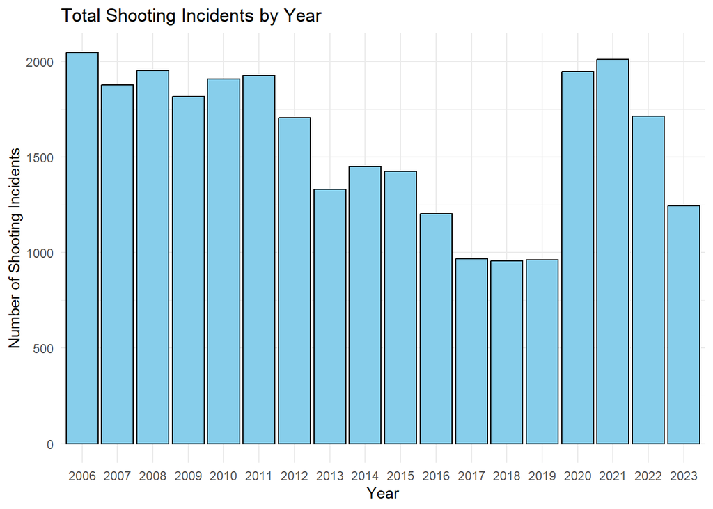

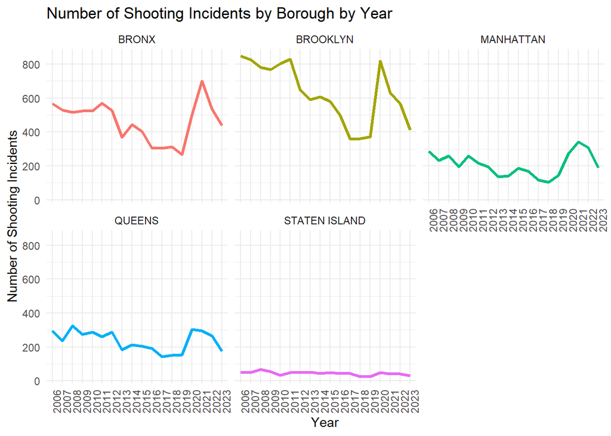

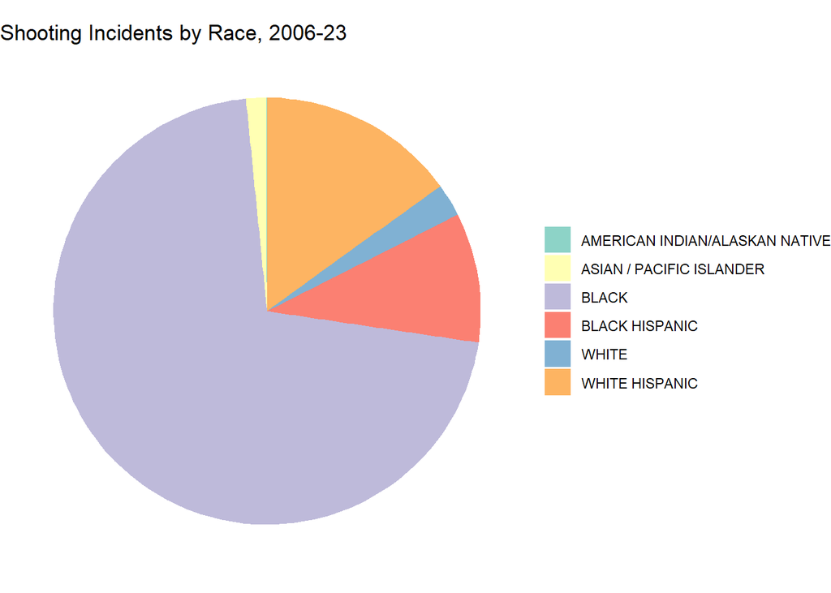

An analysis of the demographic characteristics of these crimes reveals that different communities are disproportionately affected by criminal activity. A significant number of victims were Black. White Hispanics and Black Hispanics also experienced higher levels of criminal activity compared to other racial groups.

## Model of crime severity

Here, I examined the likelihood and severity of shooting incidents, differentiating between incidents that led to murder and those that did not. As shown by the proportion of shooting incidents by severity, the majority were non-fatal; however, the fatality rate was still relatively high. To explore potential factors contributing to this, I applied a simple yet effective modeling approach: a linear probability model.

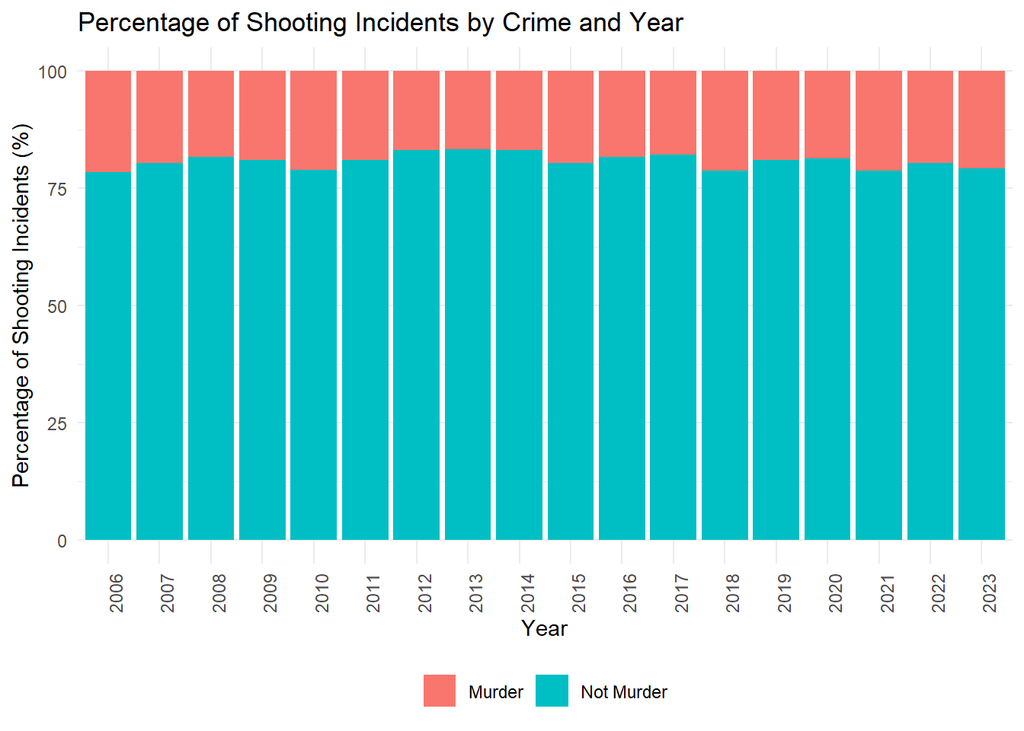

```
##
## Call:
## lm(formula = Murder ~ Male + Young + Black + Night + Brooklyn +
##     Bronx + Queens + Staten_Island, data = nypd_shooting_clean)
##
## Residuals:
##     Min      1Q  Median      3Q     Max
## -0.2539 -0.2033 -0.1841 -0.1600  0.8569
##
## Coefficients:
##                Estimate Std. Error t value Pr(>|t|)
## (Intercept)    0.220297   0.011004  20.020  < 2e-16 ***
## Male          -0.005693   0.007917  -0.719 0.472077
## Young         -0.040992   0.004872  -8.414  < 2e-16 ***
## Black         -0.011087   0.005318  -2.085 0.037103 *
## Night         -0.019402   0.005442  -3.565 0.000364 ***
## Brooklyn       0.017736   0.007505   2.363 0.018123 *
## Bronx          0.016854   0.007763   2.171 0.029935 *
## Queens         0.019195   0.008846   2.170 0.030020 *
## Staten_Island  0.033638   0.015333   2.194 0.028252 *
## ---
## Signif. codes:  0 '***' 0.001 '**' 0.01 '*' 0.05 '.' 0.1 ' ' 1
##
## Residual standard error: 0.3944 on 28438 degrees of freedom
## Multiple R-squared:  0.003528,   Adjusted R-squared:  0.003248
## F-statistic: 12.59 on 8 and 28438 DF,  p-value: < 2.2e-16
```

The model runs a regression of murder on indicators such as gender (male), age (youth, 18-24), race (Black), and location. As shown by the estimates, the model does not explain much of the variation in the likelihood of murder, so caution is necessary when drawing conclusions. However, the estimates reveal interesting and sometimes counterintuitive results: there is no significant difference between males and females, youth and Black individuals were less likely to be killed, nighttime shootings were negatively associated with the likelihood of murder, and compared with Manhattan, the other boroughs appeared to have a higher chance of a shooting incident being fatal.

## Conclusion

The analysis showed a declining trend in shooting incidents over time until the COVID-19 pandemic, during which incidents significantly increased. It also highlighted the uneven distribution of shooting incidents across different locations and communities. Additionally, a simple model was applied to examine the relationship between victim characteristics, location of incidents, and the fatality of the incidents. However, the model lacked predictive power.

Despite the useful insights from the descriptive analysis, interpretation of the results requires caution. A main source of bias may be due to a premature conclusion from the descriptive statistics that shooting incidents are inherent to certain locations or demographic behaviors. However, this is erroneous because the model did not account for variables known to have a strong relationship with crime. For example, the negative significant coefficient for Black individuals, despite a high number of shooting incidents among Blacks, could be due to the failure to control for key socioeconomic factors, which may lead to biased estimates and conclusions. These factors include household income, age distribution, population composition and density, and the level of policing activity. The descriptive analysis provides key steppingstones for more rigorous and causal analysis. Therefore, it is necessary to collect more data and run additional robustness checks.

**Additional material**

GitHub: https://github.com/kgmaysd/NYC-Shooting-Incident